# Assignment 2 - Logistic Regression

ITAO 40420 - Machine Learning

29 January 2021

# Assignment 2

For this analysis we will be using churn data. The dataset is stored as `churn_data.rda` which can be loaded in by running the below command if the file is located in your working directory or else by accessing the file through file->open file

```r
load("churn_data.rda") # Load churn dataset
```

We can view a summary of this dataset by running `summary()`:

```r
summary(churn_data)
```

```
##     gender          SeniorCitizen      Partner           Dependents
##  Length:7032        Min.   :0.0000   Length:7032        Length:7032
##  Class :character   1st Qu.:0.0000   Class :character   Class :character
##  Mode  :character   Median :0.0000   Mode  :character   Mode  :character
##                     Mean   :0.1624
##                     3rd Qu.:0.0000
##                     Max.   :1.0000
##      tenure      PhoneService       MultipleLines      InternetService
##  Min.   : 1.00   Length:7032        Length:7032        Length:7032
##  1st Qu.: 9.00   Class :character   Class :character   Class :character
##  Median :29.00   Mode  :character   Mode  :character   Mode  :character
##  Mean   :32.42
##  3rd Qu.:55.00
##  Max.   :72.00
##  OnlineSecurity     OnlineBackup       DeviceProtection   TechSupport
##  Length:7032        Length:7032        Length:7032        Length:7032
##  Class :character   Class :character   Class :character   Class :character
##  Mode  :character   Mode  :character   Mode  :character   Mode  :character
##
##
##
##  StreamingTV        StreamingMovies      Contract         PaperlessBilling
##  Length:7032        Length:7032        Length:7032        Length:7032
##  Class :character   Class :character   Class :character   Class :character
##  Mode  :character   Mode  :character   Mode  :character   Mode  :character
##
##
##
##  PaymentMethod      MonthlyCharges    TotalCharges        Churn
##  Length:7032        Min.   : 18.25   Min.   :  18.8   Min.   :0.0000
##  Class :character   1st Qu.: 35.59   1st Qu.: 401.4   1st Qu.:0.0000
##  Mode  :character   Median : 70.35   Median :1397.5   Median :0.0000
##                     Mean   : 64.80   Mean   :2283.3   Mean   :0.2658
##                     3rd Qu.: 89.86   3rd Qu.:3794.7   3rd Qu.:1.0000
##                     Max.   :118.75   Max.   :8684.8   Max.   :1.0000
```

The variables we have are:

- Gender - Whether the customer is a male or a female
- SeniorCitizen - Whether the customer is a senior citizen or not (1,0)
- Partner - Whether the customer has a partner or nor (Yes, No)
- Dependents - Whether the customer has dependents or not (Yes, No)
- tenure - Number of months the customer has stayed with the company
- PhoneService - Whether the customer has a phone service of no (Yes, No)
- MultipleLines - Whether the customer has multiple lines or not (Yes, No, No phone service)
- InternetService - Customer’s internet service provider (DSL, Fiber optic, No)
- OnlineSecurity - Whether the customer has online security or not (Yes, No, No internet service)
- OnlineBackup - Whether the customer has online backup or not (Yes, No, No internet service)
- DeviceProtection - Whether the customer has tech support or not (Yes, No, No internet service)
- StreamingTV - Whether the customer has streaming TV or not (Yes, No, No internet service)
- StreamingMovies - Whether the customer has streaming movies or not (Yes, No, No internet service)
- Contract - The contract term of the customer (Month-to-month, One year, Two year)
- PaperlessBilling - Whether the customer has paperless billing or not (Yes, No)
- PaymentMethod - The customer’s payment method (Electronic CHECK, Mailed check, Bank transfer (automatic), Credit card (automatic))
- MonthlyCharges - The amount charged to the customer monthly
- TotalCharges - The total amount charged to the customer
- Churn - Whether the customer churned or not (1 = Yes or 0 = No)

The response variable for this dataset is `Churn`:

```r
summary(as.factor(churn_data$Churn))
```

```
##    0    1
## 5163 1869
```

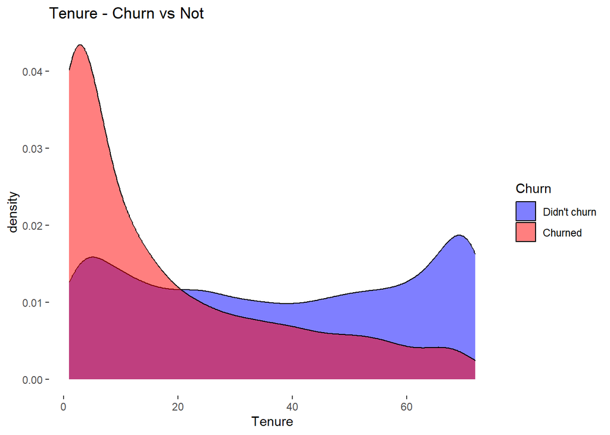

```r
plot_data <- churn_data
plot_data$Churn <- as.factor(churn_data$Churn)
g_1 <- ggplot(plot_data, aes(x = tenure, fill = Churn)) + # Set x as mean radius and fill as diagnosis
  geom_density(alpha = 0.5) + # Select density plot and set transperancy (alpha)
    theme_set(theme_bw(base_size = 22) ) + # Set theme and text size
  theme(panel.grid.major = element_blank(), # Remove grid
        panel.grid.minor = element_blank(), # Remove grid
        panel.border = element_blank(), # Remove grid
        panel.background = element_blank()) + # Remove grid
  labs(x = "Tenure", title = "Tenure - Churn vs Not",
       fill = "Churn") + # Set labels
  scale_fill_manual(values = c("1" = "red", "0" = "blue"), # Set fill colors manually
                    labels = c("1" = "Churned", "0" = "Didn't churn")) # Set labels for fill
g_1 # Generate plot
```

This would be an ok predictor as there is some distinction at the tail ends, however there is lots of overlap in the middle

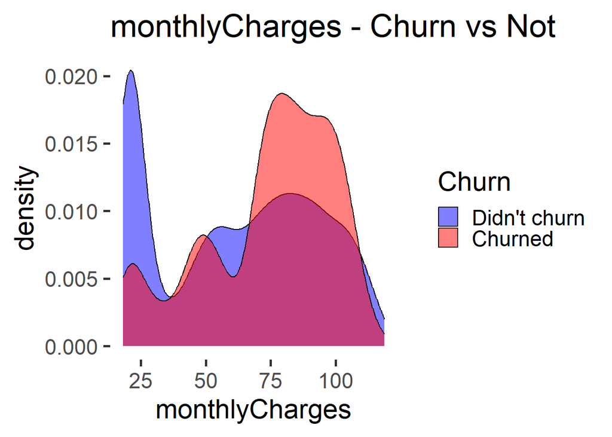

```r
g_2 <- ggplot(plot_data, aes(x = MonthlyCharges, fill = Churn)) + # Set x as mean radius and fill as diagnosis
  geom_density(alpha = 0.5) + # Select density plot and set transperancy (alpha)
    theme_set(theme_bw(base_size = 22) ) + # Set theme and text size
  theme(panel.grid.major = element_blank(), # Remove grid
        panel.grid.minor = element_blank(), # Remove grid
        panel.border = element_blank(), # Remove grid
        panel.background = element_blank()) + # Remove grid
  labs(x = "monthlyCharges", title = "monthlyCharges - Churn vs Not",
       fill = "Churn") + # Set labels
  scale_fill_manual(values = c("1" = "red", "0" = "blue"), # Set fill colors manually
                    labels = c("1" = "Churned", "0" = "Didn't churn")) # Set labels for fill
g_2 # Generate plot
```

This wouldn’t be a great predictor as there is overlap the whole way through for both

```r
fit_1 <- glm(Churn ~ ., # Set formula
             family=binomial(link='logit'), # Set logistic regression
             data= churn_data) # Set dataset
summary(fit_1) # Sumamrize model
```

```
##
## Call:
## glm(formula = Churn ~ ., family = binomial(link = "logit"), data = churn_data)
##
## Coefficients: (7 not defined because of singularities)
##                                        Estimate Std. Error z value Pr(>|z|)
## (Intercept)                           1.165e+00  8.151e-01   1.430  0.15284
## genderMale                           -2.183e-02  6.480e-02  -0.337  0.73619
## SeniorCitizen                         2.168e-01  8.453e-02   2.564  0.01033 *
## PartnerYes                           -3.840e-04  7.783e-02  -0.005  0.99606
## DependentsYes                        -1.485e-01  8.973e-02  -1.655  0.09796 .
## tenure                               -6.059e-02  6.236e-03  -9.716  < 2e-16 ***
## PhoneServiceYes                       1.715e-01  6.487e-01   0.264  0.79153
## MultipleLinesNo phone service                NA         NA      NA       NA
## MultipleLinesYes                      4.484e-01  1.773e-01   2.530  0.01142 *
## InternetServiceFiber optic            1.747e+00  7.981e-01   2.190  0.02855 *
## InternetServiceNo                    -1.786e+00  8.073e-01  -2.213  0.02691 *
## OnlineSecurityNo internet service            NA         NA      NA       NA
## OnlineSecurityYes                    -2.054e-01  1.787e-01  -1.150  0.25031
## OnlineBackupNo internet service              NA         NA      NA       NA
## OnlineBackupYes                       2.604e-02  1.754e-01   0.148  0.88197
## DeviceProtectionNo internet service          NA         NA      NA       NA
## DeviceProtectionYes                   1.474e-01  1.764e-01   0.836  0.40339
## TechSupportNo internet service               NA         NA      NA       NA
## TechSupportYes                       -1.805e-01  1.806e-01  -0.999  0.31759
## StreamingTVNo internet service               NA         NA      NA       NA
## StreamingTVYes                        5.905e-01  3.263e-01   1.810  0.07035 .
## StreamingMoviesNo internet service           NA         NA      NA       NA
## StreamingMoviesYes                    5.993e-01  3.267e-01   1.834  0.06658 .
## ContractOne year                     -6.608e-01  1.076e-01  -6.142 8.15e-10 ***
## ContractTwo year                     -1.357e+00  1.764e-01  -7.691 1.46e-14 ***
## PaperlessBillingYes                   3.424e-01  7.450e-02   4.596 4.31e-06 ***
## PaymentMethodCredit card (automatic) -8.779e-02  1.141e-01  -0.770  0.44156
## PaymentMethodElectronic check         3.045e-01  9.450e-02   3.222  0.00127 **
## PaymentMethodMailed check            -5.759e-02  1.149e-01  -0.501  0.61627
## MonthlyCharges                       -4.034e-02  3.176e-02  -1.270  0.20392
## TotalCharges                          3.289e-04  7.063e-05   4.657 3.20e-06 ***
## ---
## Signif. codes:  0 '***' 0.001 '**' 0.01 '*' 0.05 '.' 0.1 ' ' 1
##
## (Dispersion parameter for binomial family taken to be 1)
##
##     Null deviance: 8143.4  on 7031  degrees of freedom
## Residual deviance: 5826.3  on 7008  degrees of freedom
## AIC: 5874.3
##
## Number of Fisher Scoring iterations: 6
```

```r
p_values <- summary(fit_1)$coefficients[, "Pr(>|z|)"]
significant_terms <- summary(fit_1)$coefficients[p_values < 0.001, ]

#Significant terms
significant_terms
```

```
##                          Estimate   Std. Error   z value     Pr(>|z|)
## tenure              -0.0605875758 6.235677e-03 -9.716279 2.570009e-22
## ContractOne year    -0.6607952874 1.075853e-01 -6.142058 8.145911e-10
## ContractTwo year    -1.3571062357 1.764452e-01 -7.691377 1.455602e-14
## PaperlessBillingYes  0.3423536429 7.449538e-02  4.595636 4.314313e-06
## TotalCharges         0.0003289402 7.062777e-05  4.657378 3.202625e-06
```

```r
#AIC: 5874.272
AIC(fit_1)
```

```
## [1] 5874.272
```

```r
fit_2 <- glm(Churn ~ . +tenure * TotalCharges, # Set formula
             family=binomial(link='logit'), # Set logistic regression
             data= churn_data) # Set dataset
summary(fit_2) # Sumamrize model
```

```
##
## Call:
## glm(formula = Churn ~ . + tenure * TotalCharges, family = binomial(link = "logit"),
##     data = churn_data)
##
## Coefficients: (7 not defined because of singularities)
##                                        Estimate Std. Error z value Pr(>|z|)
## (Intercept)                           9.401e-01  8.175e-01   1.150  0.25019
## genderMale                           -1.880e-02  6.510e-02  -0.289  0.77275
## SeniorCitizen                         2.265e-01  8.469e-02   2.674  0.00749 **
## PartnerYes                            1.330e-03  7.822e-02   0.017  0.98643
## DependentsYes                        -1.365e-01  8.988e-02  -1.518  0.12889
## tenure                               -4.804e-02  6.397e-03  -7.510 5.92e-14 ***
## PhoneServiceYes                       1.547e-01  6.496e-01   0.238  0.81174
## MultipleLinesNo phone service                NA         NA      NA       NA
## MultipleLinesYes                      4.894e-01  1.781e-01   2.748  0.00601 **
## InternetServiceFiber optic            1.753e+00  7.994e-01   2.193  0.02833 *
## InternetServiceNo                    -1.682e+00  8.086e-01  -2.080  0.03753 *
## OnlineSecurityNo internet service            NA         NA      NA       NA
## OnlineSecurityYes                    -1.893e-01  1.792e-01  -1.056  0.29082
## OnlineBackupNo internet service              NA         NA      NA       NA
## OnlineBackupYes                       2.600e-02  1.759e-01   0.148  0.88248
## DeviceProtectionNo internet service          NA         NA      NA       NA
## DeviceProtectionYes                   1.688e-01  1.767e-01   0.955  0.33956
## TechSupportNo internet service               NA         NA      NA       NA
## TechSupportYes                       -1.520e-01  1.810e-01  -0.839  0.40122
## StreamingTVNo internet service               NA         NA      NA       NA
## StreamingTVYes                        6.192e-01  3.270e-01   1.894  0.05828 .
## StreamingMoviesNo internet service           NA         NA      NA       NA
## StreamingMoviesYes                    6.259e-01  3.273e-01   1.912  0.05581 .
## ContractOne year                     -7.011e-01  1.086e-01  -6.457 1.07e-10 ***
## ContractTwo year                     -1.667e+00  1.899e-01  -8.777  < 2e-16 ***
## PaperlessBillingYes                   3.357e-01  7.496e-02   4.478 7.52e-06 ***
## PaymentMethodCredit card (automatic) -9.843e-02  1.139e-01  -0.865  0.38731
## PaymentMethodElectronic check         2.844e-01  9.467e-02   3.004  0.00267 **
## PaymentMethodMailed check            -7.076e-02  1.155e-01  -0.613  0.54010
## MonthlyCharges                       -3.424e-02  3.183e-02  -1.076  0.28202
## TotalCharges                         -2.111e-04  1.244e-04  -1.697  0.08976 .
## tenure:TotalCharges                   5.968e-06  1.153e-06   5.175 2.28e-07 ***
## ---
## Signif. codes:  0 '***' 0.001 '**' 0.01 '*' 0.05 '.' 0.1 ' ' 1
##
## (Dispersion parameter for binomial family taken to be 1)
##
##     Null deviance: 8143.4  on 7031  degrees of freedom
## Residual deviance: 5799.5  on 7007  degrees of freedom
## AIC: 5849.5
##
## Number of Fisher Scoring iterations: 6
```

```r
AIC(fit_2)
```

```
## [1] 5849.505
```

The addition of interaction term was significant and decreased AIC from 5874 to 5849.

```r
library(dplyr)
x_data <- churn_data %>% mutate_at(c(5, 18, 19), funs(c(scale(.))))
x_data$Churn <- churn_data$Churn
x_vars <- model.matrix(Churn ~.,  #model.matrix converts categorical data into binary columns
                       x_data)[,-1] #dropping col1 because it's an constant intercept col of 1s, don't want that


# Fit lasso model
lasso_fit <- glmnet(x = x_vars, # Set explantory variables
                    y = churn_data$Churn, # Set response variable
                    alpha = 1, # Set alpha value
                    family = "binomial")


set.seed(123)
# Set sequence of lambda values
lambda_seq <- 10^seq(4, -4, by = -.1)
# Fit cross-validated lasso model
cv.lasso <- cv.glmnet(x = x_vars, # Set x variables
                 y = churn_data$Churn, # Set response variables
                 alpha = 1, # Set alpha = 1 for lasso
                 family = "binomial", # Set family as binomial for logistic regression
                 lambda = lambda_seq, # Set lambda values to try
                 nfolds = 10)
best_lam <- cv.lasso$lambda.1se # Extract best lambda
best_lam  # Print best lambda
```

```
## [1] 0.007943282
```

```r
lasso_fit_final <- glmnet(x = x_vars, # Set explantory variables
                    y = churn_data$Churn, # Set response variable
                    alpha = 1, # Set alpha as 1 for lasso
                    family = "binomial", # Set as logistic regression
                    lambda = best_lam) # Set lambda as best lambda


temp <- cbind.data.frame(coef(fit_1), as.vector(coef(lasso_fit_final))) # Join Coefficients from models
names(temp) <- c("LogisiticRegression", "LogisticLasso") # Name coefficient columns
rownames(temp) <- names(coef(fit_1)) # Add rownames to coefficients
temp # Print coefficients
```

```
##                                      LogisiticRegression LogisticLasso
## (Intercept)                                 1.1652874730 -1.510665e+00
## genderMale                                 -0.0218327330  0.000000e+00
## SeniorCitizen                               0.2167750381  1.778105e-01
## PartnerYes                                 -0.0003839967  0.000000e+00
## DependentsYes                              -0.1484878218 -9.459825e-02
## tenure                                     -0.0605875758 -7.679557e-01
## PhoneServiceYes                             0.1714677932 -1.976371e-01
## MultipleLinesNo phone service                         NA  0.000000e+00
## MultipleLinesYes                            0.4483954398  1.302274e-01
## InternetServiceFiber optic                  1.7474749099  8.581293e-01
## InternetServiceNo                          -1.7862947193 -5.084882e-01
## OnlineSecurityNo internet service                     NA -5.509561e-03
## OnlineSecurityYes                          -0.2054200359 -2.735554e-01
## OnlineBackupNo internet service                       NA -9.616764e-02
## OnlineBackupYes                             0.0260418496  0.000000e+00
## DeviceProtectionNo internet service                   NA -2.458829e-03
## DeviceProtectionYes                         0.1473749979  0.000000e+00
## TechSupportNo internet service                        NA -1.557807e-15
## TechSupportYes                             -0.1804968061 -2.339731e-01
## StreamingTVNo internet service                        NA -8.657609e-02
## StreamingTVYes                              0.5905074088  1.592712e-01
## StreamingMoviesNo internet service                    NA -1.494834e-03
## StreamingMoviesYes                          0.5992957142  1.753807e-01
## ContractOne year                           -0.6607952874 -5.251010e-01
## ContractTwo year                           -1.3571062357 -9.940615e-01
## PaperlessBillingYes                         0.3423536429  2.818960e-01
## PaymentMethodCredit card (automatic)       -0.0877918170  0.000000e+00
## PaymentMethodElectronic check               0.3044672709  3.641636e-01
## PaymentMethodMailed check                  -0.0575871944  0.000000e+00
## MonthlyCharges                             -0.0403435284  0.000000e+00
## TotalCharges                                0.0003289402  0.000000e+00
```

```r
#Non zero
temp[temp$LogisticLasso != 0,]
```

```
##                                     LogisiticRegression LogisticLasso
## (Intercept)                                  1.16528747 -1.510665e+00
## SeniorCitizen                                0.21677504  1.778105e-01
## DependentsYes                               -0.14848782 -9.459825e-02
## tenure                                      -0.06058758 -7.679557e-01
## PhoneServiceYes                              0.17146779 -1.976371e-01
## MultipleLinesYes                             0.44839544  1.302274e-01
## InternetServiceFiber optic                   1.74747491  8.581293e-01
## InternetServiceNo                           -1.78629472 -5.084882e-01
## OnlineSecurityNo internet service                    NA -5.509561e-03
## OnlineSecurityYes                           -0.20542004 -2.735554e-01
## OnlineBackupNo internet service                      NA -9.616764e-02
## DeviceProtectionNo internet service                  NA -2.458829e-03
## TechSupportNo internet service                       NA -1.557807e-15
## TechSupportYes                              -0.18049681 -2.339731e-01
## StreamingTVNo internet service                       NA -8.657609e-02
## StreamingTVYes                               0.59050741  1.592712e-01
## StreamingMoviesNo internet service                   NA -1.494834e-03
## StreamingMoviesYes                           0.59929571  1.753807e-01
## ContractOne year                            -0.66079529 -5.251010e-01
## ContractTwo year                            -1.35710624 -9.940615e-01
## PaperlessBillingYes                          0.34235364  2.818960e-01
## PaymentMethodElectronic check                0.30446727  3.641636e-01
```

```r
pos <- temp[temp$LogisticLasso > 0,]
neg <- temp[temp$LogisticLasso < 0,]


#These are positive coefficients which means if they are present, there is an increased probability of "churning"
pos
```

```
##                               LogisiticRegression LogisticLasso
## SeniorCitizen                           0.2167750     0.1778105
## MultipleLinesYes                        0.4483954     0.1302274
## InternetServiceFiber optic              1.7474749     0.8581293
## StreamingTVYes                          0.5905074     0.1592712
## StreamingMoviesYes                      0.5992957     0.1753807
## PaperlessBillingYes                     0.3423536     0.2818960
## PaymentMethodElectronic check           0.3044673     0.3641636
```

```r
#These are negative coefficients which means if they are present, there is an decreased probability of "churning"
neg
```

```
##                                     LogisiticRegression LogisticLasso
## (Intercept)                                  1.16528747 -1.510665e+00
## DependentsYes                               -0.14848782 -9.459825e-02
## tenure                                      -0.06058758 -7.679557e-01
## PhoneServiceYes                              0.17146779 -1.976371e-01
## InternetServiceNo                           -1.78629472 -5.084882e-01
## OnlineSecurityNo internet service                    NA -5.509561e-03
## OnlineSecurityYes                           -0.20542004 -2.735554e-01
## OnlineBackupNo internet service                      NA -9.616764e-02
## DeviceProtectionNo internet service                  NA -2.458829e-03
## TechSupportNo internet service                       NA -1.557807e-15
## TechSupportYes                              -0.18049681 -2.339731e-01
## StreamingTVNo internet service                       NA -8.657609e-02
## StreamingMoviesNo internet service                   NA -1.494834e-03
## ContractOne year                            -0.66079529 -5.251010e-01
## ContractTwo year                            -1.35710624 -9.940615e-01
```

For the assignment please carry out the following tasks/answer the following questions: (12 Points)

- 1 - Create at least two visualizations potentially revealing factors with predictive power (2 Points)
- 2 - Fit a logistic regression model to the data. (Remember you can use `resp ~.,` to include all explanatory variables in the model) (2 Points)
- 3 - What features are significant in your logistic regression model? (1 Point)
- 4 - What is the AIC of your logistic regression model? (1 Point)
- 5 - Add an interaction term to the logistic regression model? (1 Point)
- 6 - Does the addition of the interaction term increase or decrease the AIC? What is the new AIC for the model? (1 Point)
- 7 - Fit a lasso logistic regression model to the data. (1 Point)
- 8 - Which coefficients were non-zero in the lasso model? Were they positive or negative? What does this imply? (1 Point)

2 Points for analysis decisions and code quality.

Please submit an an R-markdown document with the answers, optionally you can submit an R-script with the code used for your analysis and a document answering the specific questions, you can use word, pdf etc.

Assignments can be submitted via Canvas or by email to mbarron2@nd.edu.